# Analyse Axe1

Eya

2024-01-02

##Import des données

```r
library(dplyr)
data2018 <- read.csv("../2018.csv")
data2019 <- read.csv("../2019.csv")
data2020 <- read.csv("../2020.csv")
data2021 <- read.csv("../2021.csv")
data2022 <- read.csv("../2022.csv")
data2023 <- read.csv("../2023_axe1.csv")

#homogénéisation de colonnes
data2020<- data2020 %>% rename(sexe = Genre)
data2021<- data2021 %>% rename(sexe = Genre)
data2022<- data2022 %>% rename(sexe = Genre)

# Conversion des identifiants de la notation scientifique
data2019$identifiant <- as.numeric(format(data2019$identifiant, scientific = FALSE))
```

##Selection des colonnes :

```r
library(dplyr)

data2018 <- select(data2018, sexe, identifiant, date_diplome, filiere, remuneration_annuelle_brute, prime, remuneration_prime, remuneration_annuelle_brute_hors_prime_premier_emploi,nationalite_francaise,nationalite, prime_premier_emploi, remuneration_annuelle_brute_avec_prime_premier_emploi)

data2019 <- select(data2019, sexe, identifiant, date_diplome, filiere, remuneration_annuelle_brute, prime, remuneration_prime, remuneration_annuelle_brute_hors_prime_premier_emploi,nationalite_francaise,nationalite, prime_premier_emploi, remuneration_annuelle_brute_avec_prime_premier_emploi)

data2020 <- select(data2020, sexe, identifiant, date_diplome, filiere, remuneration_annuelle_brute, prime, remuneration_prime, remuneration_annuelle_brute_hors_prime_premier_emploi,nationalite_francaise,nationalite, prime_premier_emploi, remuneration_annuelle_brute_avec_prime_premier_emploi)

data2021 <- select(data2021, sexe, identifiant, date_diplome, filiere, remuneration_annuelle_brute, prime, remuneration_prime, remuneration_annuelle_brute_hors_prime_premier_emploi,nationalite_francaise,nationalite, prime_premier_emploi, remuneration_annuelle_brute_avec_prime_premier_emploi)

data2022 <- select(data2022, sexe, identifiant, date_diplome, filiere, remuneration_annuelle_brute, prime, remuneration_prime, remuneration_annuelle_brute_hors_prime_premier_emploi,nationalite_francaise,nationalite, prime_premier_emploi, remuneration_annuelle_brute_avec_prime_premier_emploi)

data2023 <- select(data2023, sexe, identifiant, date_diplome, filiere, remuneration_annuelle_brute, prime, remuneration_prime, remuneration_annuelle_brute_hors_prime_premier_emploi,nationalite_francaise,nationalite, prime_premier_emploi, remuneration_annuelle_brute_avec_prime_premier_emploi)
```

##Fusion des jeux de données

```r
donnees_totales <- rbind(data2018, data2019, data2020, data2021, data2022, data2023)
```

##Analyse Exploratoire des données L’Analyse exploratoire des données est une étape cruciale dans tout projet de data science car elle nous permet de comprendre les tendances, les motifs, les anomalies et les relations dans nos données. démarche que nous avons effectuée dans nos analyses et qui nous a permi de corriger certaines anomalies qui peuvent fausser nos résultats.

```r
#vérifier si le jeu de données a bien été crée :
exists("donnees_totales")
```

```
## [1] TRUE
```

```r
#aperçu des premières lignes
head(donnees_totales)
```

```
##    sexe      identifiant date_diplome                                filiere
## 1 Homme 1877069833744240         2017 Microélectronique Et Automatique (MEA)
## 2 Homme 1867772706661410         2017 Microélectronique Et Automatique (MEA)
## 3 Homme 1783164948056770         2017 Microélectronique Et Automatique (MEA)
## 4 Homme 1777070157836320         2017 Microélectronique Et Automatique (MEA)
## 5 Homme 1885320205889630         2017 Microélectronique Et Automatique (MEA)
## 6 Homme 1782336119224670         2017 Microélectronique Et Automatique (MEA)
##   remuneration_annuelle_brute prime remuneration_prime
## 1                       31500   Non              31500
## 2                       33000   Oui              33000
## 3                       36000   Oui              36000
## 4                        <NA>                     <NA>
## 5                        <NA>                     <NA>
## 6                       32000   Non              32000
##   remuneration_annuelle_brute_hors_prime_premier_emploi nationalite_francaise
```

[output cut: 20 more lines]

```r
#résumé statistique de chaque colonne dans ton dataframe
summary(donnees_totales)
```

```
##      sexe           identifiant         date_diplome    filiere
##  Length:4419        Length:4419        Min.   : 721   Length:4419
##  Class :character   Class :character   1st Qu.:2017   Class :character
##  Mode  :character   Mode  :character   Median :2019   Mode  :character
##                                        Mean   :2018
##                                        3rd Qu.:2020
##                                        Max.   :2022
##                                        NA's   :6
##  remuneration_annuelle_brute    prime           remuneration_prime
##  Length:4419                 Length:4419        Length:4419
##  Class :character            Class :character   Class :character
##  Mode  :character            Mode  :character   Mode  :character
##
##
##
##
##  remuneration_annuelle_brute_hors_prime_premier_emploi nationalite_francaise
##  Min.   : 1500                                         Length:4419
##  1st Qu.:25128                                         Class :character
##  Median :30000                                         Mode  :character
##  Mean   :29458
##  3rd Qu.:33000
##  Max.   :77220
##  NA's   :3728
##  nationalite        prime_premier_emploi
##  Length:4419        Length:4419
##  Class :character   Class :character
##  Mode  :character   Mode  :character
##
##
##
##
##  remuneration_annuelle_brute_avec_prime_premier_emploi
##  Min.   : 1500
##  1st Qu.:26400
##  Median :31000
##  Mean   :30784
##  3rd Qu.:35000
##  Max.   :83700
##  NA's   :3729
```

```r
#Structure du jeu de données
str(donnees_totales)
```

```
## 'data.frame':    4419 obs. of  12 variables:
##  $ sexe                                                 : chr  "Homme" "Homme" "Homme" "Homme" ...
##  $ identifiant                                          : chr  "1877069833744240" "1867772706661410" "1783164948056770" "1777070157836320" ...
##  $ date_diplome                                         : num  2017 2017 2017 2017 2017 ...
##  $ filiere                                              : chr  "Microélectronique Et Automatique (MEA)" "Microélectronique Et Automatique (MEA)" "Microélectronique Et Automatique (MEA)" "Microélectronique Et Automatique (MEA)" ...
##  $ remuneration_annuelle_brute                          : chr  "31500" "33000" "36000" NA ...
##  $ prime                                                : chr  "Non" "Oui" "Oui" "" ...
##  $ remuneration_prime                                   : chr  "31500" "33000" "36000" NA ...
##  $ remuneration_annuelle_brute_hors_prime_premier_emploi: num  NA NA NA 29000 NA NA NA NA NA NA ...
##  $ nationalite_francaise                                : chr  "Non" "Oui" "Oui" "Oui" ...
##  $ nationalite                                          : chr  "Belge" "" "" "" ...
##  $ prime_premier_emploi                                 : chr  "" "" "" "Non" ...
##  $ remuneration_annuelle_brute_avec_prime_premier_emploi: num  NA NA NA 29000 NA NA NA NA NA NA ...
```

```r
#dimensions du jeu de données
dim(donnees_totales)
```

```
## [1] 4419   12
```

La structure de cette partie du jeu de données contient 4419 observations et 12 variables.

La dimension du jeu de données est de 4419 observations (lignes) et 12 variables (colonnes). Les nombreuses valeurs manquantes (NA) dans certaines seront traitées dans la suite de l’Analyse.

## Avoir les occurences des identifiants

Nous allons explorer les données et voir combien de fois les diplomés ont répondus à l’enquête

```r
#Compter les occurences de chaque identifiant
identifiant_counts <- table(donnees_totales$identifiant)

# Afficher le tableau
identifiant_counts
```

[output not shown]

[output cut: 1200 more lines]

```r
# Dans ton fichier R Markdown

library(knitr)

identifiant_counts_df <- as.data.frame(identifiant_counts)
colnames(identifiant_counts_df) <- c("Identifiant", "Nombre_d_occurrences")

kable(identifiant_counts_df)
```

| Identifiant | Nombre_d_occurrences |
| --- | --- |
|  | 6 |
| #REF! | 1 |
| #VALEUR! | 1 |
| 1742932406541910 | 2 |
| 1744206698907320 | 1 |
| 1746218061142890 | 1 |
| 1756544615604770 | 1 |
| 1756662215309860 | 1 |
| 1756804520498890 | 1 |
| 1756804883322830 | 2 |
| 1756804884496880 | 1 |
| 1757247289876320 | 1 |
| 1757379921945330 | 1 |
| 1757599076256500 | 1 |
| 1757599076417900 | 1 |
| 1757599424478080 | 1 |
| 1757617280501340 | 1 |
| 1757617753913660 | 1 |
| 1757709831693380 | 2 |
| 1757709965251920 | 3 |
| 1758308385440000 | 1 |
| 1758523041000500 | 1 |
| 1758523132419240 | 2 |
| 1758523254310480 | 1 |
| 1758626743656350 | 1 |
| 1758626839506070 | 1 |
| 1758627194075820 | 3 |
| 1759194862955800 | 1 |
| 1759195102887890 | 3 |
| 1759195423053240 | 1 |

[output cut: 2396 more lines]

## Identifiants réccurents seulement

Ici, nous allons sélectionnées seulement, les personnes qui ont répondus plusieurs fois à l’enquête

```r
library(knitr)

# Création du data.frame des identifiants récurrents et leurs occurrences
identifiants_recurrents <- identifiant_counts[identifiant_counts > 1]
identifiants_recurrents_df <- data.frame(Identifiant = names(identifiants_recurrents),
                                         Occurrences = as.integer(identifiants_recurrents))

# Utilisation de kable pour un joli affichage en tableau
kable(identifiants_recurrents_df)
```

| Identifiant | Occurrences |
| --- | --- |
|  | 6 |
| 1742932406541910 | 2 |
| 1756804883322830 | 2 |
| 1757709831693380 | 2 |
| 1757709965251920 | 3 |
| 1758523132419240 | 2 |
| 1758627194075820 | 3 |
| 1759195102887890 | 3 |
| 1766809397136680 | 2 |
| 1766816750910820 | 3 |
| 1766816763108060 | 3 |
| 1766816763164740 | 2 |
| 1766816841421730 | 3 |
| 1766817026164020 | 3 |
| 1766817679604640 | 3 |
| 1766825151490760 | 3 |
| 1766828031937710 | 2 |
| 1766828215737030 | 2 |
| 1767188220767320 | 3 |
| 1767188974163000 | 2 |
| 1767189237564080 | 2 |
| 1767189251505240 | 2 |
| 1767189251615070 | 2 |
| 1767189979904520 | 2 |
| 1767190160340410 | 3 |
| 1767190268463680 | 2 |
| 1767190347040890 | 2 |
| 1767198402827670 | 2 |
| 1767270430761410 | 3 |
| 1767362520512390 | 2 |

[output cut: 946 more lines]

Ici, nous avons une vue de toutes les colonnes pour les individus qui ont répondus plusieurs fois.

```r
library(knitr)
library(kableExtra)
# Filtrer les données pour obtenir seulement les entrées avec des identifiants récurrents
donnees_recurrentes <- donnees_totales[donnees_totales$identifiant %in% names(identifiants_recurrents), ]

# Utilisation de kable pour un joli affichage en tableau des premières lignes
kable(head(donnees_recurrentes), "html", escape = FALSE) %>%
  kable_styling(full_width = F) %>%
  column_spec(1:ncol(donnees_recurrentes),
              extra_css = "padding-left:10px; padding-right:10px; text-align:center;")
```

|  | sexe | identifiant | date_diplome | filiere | remuneration_annuelle_brute | prime | remuneration_prime | remuneration_annuelle_brute_hors_prime_premier_emploi | nationalite_francaise | nationalite | prime_premier_emploi | remuneration_annuelle_brute_avec_prime_premier_emploi |
| --- | --- | --- | --- | --- | --- | --- | --- | --- | --- | --- | --- | --- |
| 1 | Homme | 1877069833744240 | 2017 | Microélectronique Et Automatique (MEA) | 31500 | Non | 31500 | NA | Non | Belge |  | NA |
| 3 | Homme | 1783164948056770 | 2017 | Microélectronique Et Automatique (MEA) | 36000 | Oui | 36000 | NA | Oui |  |  | NA |
| 4 | Homme | 1777070157836320 | 2017 | Microélectronique Et Automatique (MEA) | NA |  | NA | 29000 | Oui |  | Non | 29000 |
| 6 | Homme | 1782336119224670 | 2017 | Microélectronique Et Automatique (MEA) | 32000 | Non | 32000 | NA | Oui |  |  | NA |
| 7 | Homme | 1802846092404660 | 2017 | Microélectronique Et Automatique (MEA) | NA |  | NA | NA | Oui |  |  | NA |
| 8 | Femme | 1782455519326140 | 2017 | Microélectronique Et Automatique (MEA) | 29000 | Non | 29000 | NA | Oui |  |  | NA |

## Identifiants non récurrents seulement

Nous allons sélectionner les individus qui ont répondus qu’une seule fois à l’enquête

```r
library(knitr)

# Création du data frame des identifiants non récurrents et leurs occurrences
identifiants_non_recurrents <- identifiant_counts[identifiant_counts == 1]
identifiants_non_recurrents_df <- data.frame(Identifiant = names(identifiants_non_recurrents),
                                             Occurrences = as.integer(identifiants_non_recurrents))

# Utilisation de kable pour un joli affichage en tableau
kable(identifiants_non_recurrents_df) %>%
  kable_styling(full_width = F) %>%
  column_spec(1:2,
              extra_css = "padding-left:10px; padding-right:10px; text-align:center;")
```

| Identifiant | Occurrences |
| --- | --- |
| #REF! | 1 |
| #VALEUR! | 1 |
| 1744206698907320 | 1 |
| 1746218061142890 | 1 |
| 1756544615604770 | 1 |
| 1756662215309860 | 1 |
| 1756804520498890 | 1 |
| 1756804884496880 | 1 |
| 1757247289876320 | 1 |
| 1757379921945330 | 1 |
| 1757599076256500 | 1 |
| 1757599076417900 | 1 |
| 1757599424478080 | 1 |
| 1757617280501340 | 1 |
| 1757617753913660 | 1 |
| 1758308385440000 | 1 |
| 1758523041000500 | 1 |
| 1758523254310480 | 1 |
| 1758626743656350 | 1 |
| 1758626839506070 | 1 |
| 1759194862955800 | 1 |
| 1759195423053240 | 1 |
| 1766809577162840 | 1 |
| 1766816933705740 | 1 |
| 1766818797606270 | 1 |
| 1766818808739340 | 1 |
| 1766828029067780 | 1 |
| 1766828308955400 | 1 |
| 1767188038511560 | 1 |
| 1767188224335030 | 1 |

[output cut: 1420 more lines]

Et pareil, ici nous avons un tableau avec toutes les colonnes pour les individus qui ont répondus une seule fois

```r
library(knitr)
library(kableExtra)

# Filtrer les données pour obtenir seulement les entrées avec des identifiants non récurrents
donnees_non_recurrentes <- donnees_totales[!donnees_totales$identifiant %in% names(identifiants_recurrents), ]

# Utilisation de kable pour un affichage en tableau des premières lignes
kable(head(donnees_non_recurrentes), "html", escape = FALSE) %>%
  kable_styling(full_width = F) %>%
  column_spec(1:ncol(donnees_non_recurrentes),
              extra_css = "padding-left:10px; padding-right:10px; text-align:center;")
```

|  | sexe | identifiant | date_diplome | filiere | remuneration_annuelle_brute | prime | remuneration_prime | remuneration_annuelle_brute_hors_prime_premier_emploi | nationalite_francaise | nationalite | prime_premier_emploi | remuneration_annuelle_brute_avec_prime_premier_emploi |
| --- | --- | --- | --- | --- | --- | --- | --- | --- | --- | --- | --- | --- |
| 2 | Homme | 1867772706661410 | 2017 | Microélectronique Et Automatique (MEA) | 33000 | Oui | 33000 | NA | Oui |  |  | NA |
| 5 | Homme | 1885320205889630 | 2017 | Microélectronique Et Automatique (MEA) | NA |  | NA | NA | Oui |  |  | NA |
| 17 | Homme | 1789078677755080 | 2017 | Energétique - énergies Renouvelables (EnR) | NA |  | NA | NA | Oui |  |  | NA |
| 18 | Homme | 1882519960739120 | 2017 | Energétique - énergies Renouvelables (EnR) | NA | Non | NA | NA | Oui |  |  | NA |
| 19 | Femme | 1889139174554320 | 2017 | Energétique - énergies Renouvelables (EnR) | NA |  | NA | 20000 | Oui |  | Non | 20000 |
| 20 | Homme | 1782851081127970 | 2017 | Mécanique Structures Industrielles (MSI - apprentissage) | NA |  | NA | 33000 | Oui |  | Non | 33000 |

##Analyse exploratoire des données d’individus réccurents et non réccurents

#Visualiser la distribution des salaires pour les individus avec plusieurs réponses

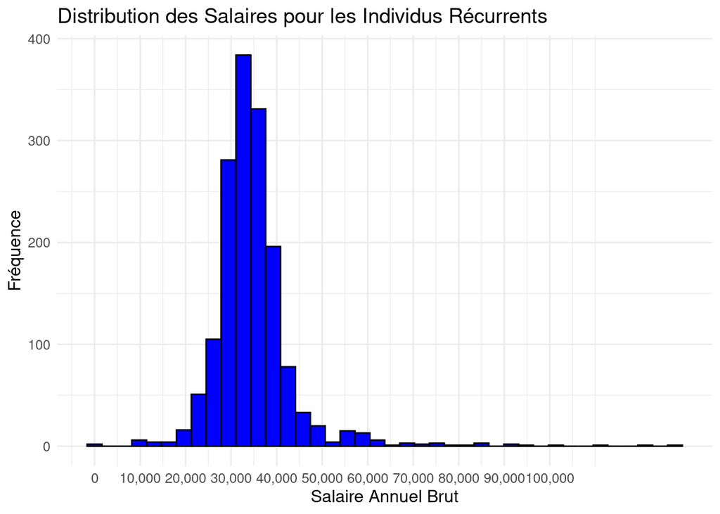

```r
library(ggplot2)
library(scales) # pour la fonction comma() et pretty_breaks

# Histogramme des salaires pour les individus récurrents

# Définir les repères de l'axe des abscisses
breaks_pretty <- pretty(donnees_recurrentes$remuneration_annuelle_brute, n = 7) # 'n' définit le nombre souhaité de repères
# Convertir 'remuneration_annuelle_brute' en numèrique et gérer les virgules
# donnees_recurrentes$remuneration_annuelle_brute <- gsub(",", "", donnees_recurrentes$remuneration_annuelle_brute) # Remove commas if any
donnees_recurrentes$remuneration_annuelle_brute <- as.numeric(donnees_recurrentes$remuneration_annuelle_brute)
ggplot(donnees_recurrentes, aes(x = remuneration_annuelle_brute)) +
  geom_histogram(bins = 40, fill = "blue", color = "black") +
  scale_x_continuous(
    breaks = breaks_pretty, # Utiliser les repères générés par pretty()
    labels = scales::label_comma() # Utiliser label_comma pour un formatage correct des nombres
  ) +
  labs(
    title = "Distribution des Salaires pour les Individus Récurrents",
    x = "Salaire Annuel Brut",
    y = "Fréquence"
  ) +
  theme_minimal() +
  theme(text = element_text(size = 12))
```

Interprétation de l’histogramme ci-dessus :

L’histogramme illustre la distribution des salaires annuels bruts pour l’ensemble d’individus récurrents. La distribution semble être centrée autour de la médiane, avec une concentration élevée de salaires dans la fourchette moyenne. La forme de l’histogramme suggère une distribution assez symétrique avec une légère inclinaison vers la droite, indiquant que quelques individus ont des salaires nettement plus élevés que la majorité, ce qui est typique d’une distribution de revenus.

La fréquence la plus élevée se trouve dans l’intervalle de salaire qui pourrait être estimé entre environ 30 000 et 40 000, ce qui pourrait être considéré comme le salaire annuel brut le plus commun au sein de cet échantillon. Les barres décroissent à mesure que l’on s’éloigne de cette fourchette centrale, ce qui montre que les salaires extrêmement bas ou extrêmement élevés sont moins fréquents.

Boxplot des salaires des individus réccurents :

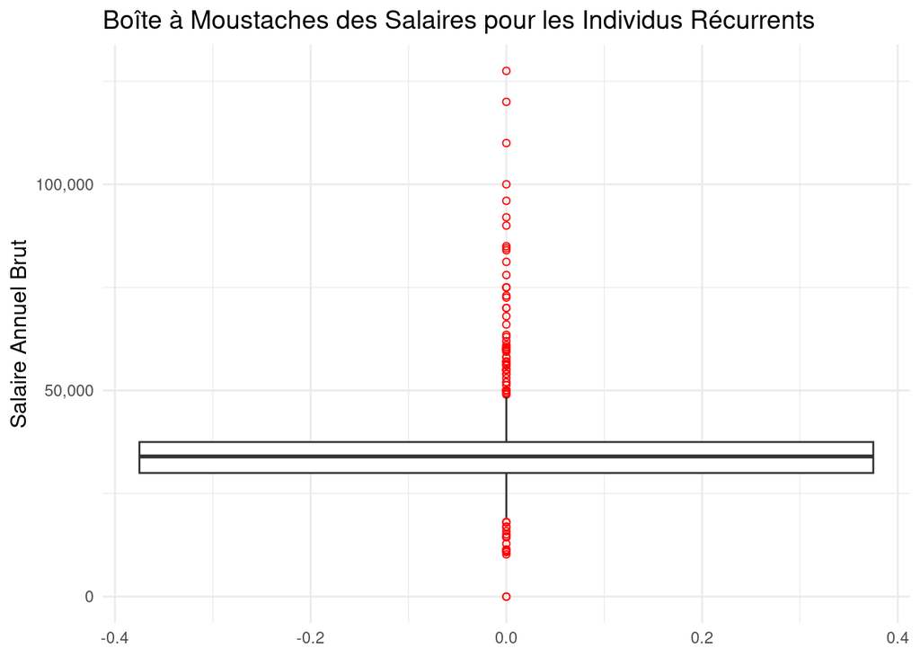

```r
library(ggplot2)
library(scales)  # pour les fonctions de formatage

# Boîte à moustaches pour voir la dispersion et les éventuels outliers
ggplot(donnees_recurrentes, aes(y = remuneration_annuelle_brute)) +
  geom_boxplot(outlier.colour = "red", outlier.shape = 1) +
  scale_y_continuous(labels = scales::comma) +
  labs(title = "Boîte à Moustaches des Salaires pour les Individus Récurrents",
       y = "Salaire Annuel Brut") +
  theme_minimal() +
    theme(
    axis.title.y = element_text(size = 12),  # Taille de texte pour les étiquettes des axes
    plot.title = element_text(size = 14)  # Taille de texte pour le titre
  )
```

#Visualiser la distribution des salaires pour les individus non réccurents

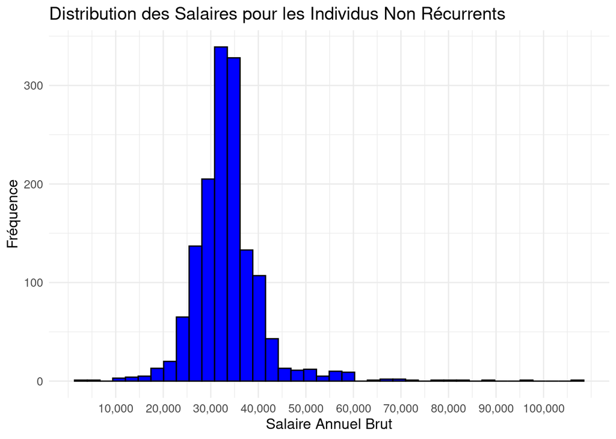

```r
library(ggplot2)
library(scales) # pour la fonction comma() et pretty_breaks

# Histogramme des salaires pour les individus récurrents

# Définir les repères de l'axe des abscisses
breaks_pretty <- pretty(donnees_non_recurrentes$remuneration_annuelle_brute, n = 7) # 'n' définit le nombre souhaité de repères

# Convertir 'remuneration_annuelle_brute' en numèrique et gérer les virgules
# donnees_non_recurrentes$remuneration_annuelle_brute <- gsub(",", "", donnees_recurrentes$remuneration_annuelle_brute) # Remove commas if any
donnees_non_recurrentes$remuneration_annuelle_brute <- as.numeric(donnees_non_recurrentes$remuneration_annuelle_brute)


ggplot(donnees_non_recurrentes, aes(x = remuneration_annuelle_brute)) +
  geom_histogram(bins = 40, fill = "blue", color = "black") +
  scale_x_continuous(
    breaks = breaks_pretty, # Utiliser les repères générés par pretty()
    labels = scales::label_comma() # Utiliser label_comma pour un formatage correct des nombres
  ) +
  labs(
    title = "Distribution des Salaires pour les Individus Non Récurrents",
    x = "Salaire Annuel Brut",
    y = "Fréquence"
  ) +
  theme_minimal() +
  theme(text = element_text(size = 12))
```

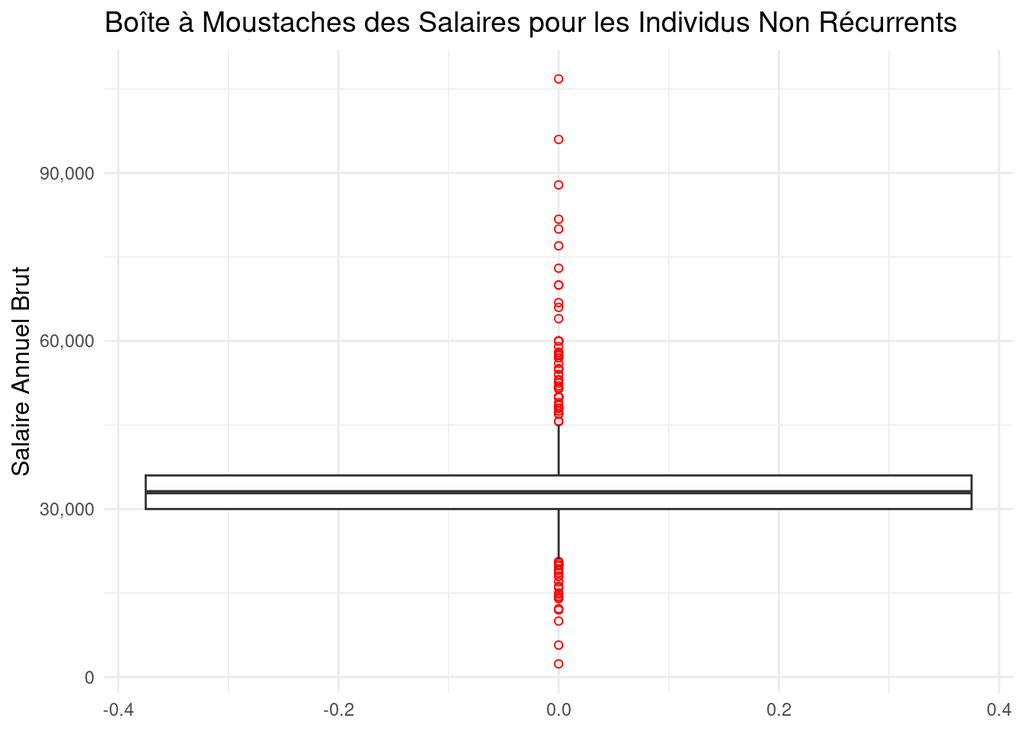

```r
library(ggplot2)
library(scales)  # pour les fonctions de formatage

# Boîte à moustaches pour voir la dispersion et les éventuels outliers
ggplot(donnees_non_recurrentes, aes(y = remuneration_annuelle_brute)) +
  geom_boxplot(outlier.colour = "red", outlier.shape = 1) +
  scale_y_continuous(labels = scales::comma) +
  labs(title = "Boîte à Moustaches des Salaires pour les Individus Non Récurrents",
       y = "Salaire Annuel Brut") +
  theme_minimal() +
    theme(
    axis.title.y = element_text(size = 12),  # Taille de texte pour les étiquettes des axes
    plot.title = element_text(size = 14)  # Taille de texte pour le titre
  )
```

#Calcul des moyennes de salaires des individus qui ont répondus plusieurs fois Pour les individus qui ont fourni plusieurs réponses concernant leur salaire annuel brut, nous procéderons à un calcul de la moyenne de ces salaires afin d’obtenir une valeur représentative unique pour chaque personne. Cela nous permettra de poursuivre notre analyse de façon cohérente et précise pour cet aspect spécifique de l’étude.

```r
library(dplyr)

# Convertir la colonne remuneration_prime en numérique si elle est de type caractère
donnees_recurrentes <- donnees_recurrentes %>%
  mutate(remuneration_prime = as.numeric(as.character(remuneration_prime)))
donnees_non_recurrentes <- donnees_non_recurrentes %>%
  mutate(remuneration_prime = as.numeric(as.character(remuneration_prime)))

# Calculer la moyenne des salaires pour chaque individu récurrent
#salaire_moyen_individus_recurrents <- donnees_recurrentes %>%
#  group_by(identifiant,sexe) %>%
#  summarize(moyenne_salaire = mean(remuneration_annuelle_brute, na.rm = TRUE)) %>%
#  ungroup()  # Pour retirer le groupement après la summarization

salaire_moyen_individus_recurrents <- donnees_recurrentes %>%
  group_by(identifiant) %>%
  summarize(
    remuneration_annuelle_brute = mean(remuneration_annuelle_brute, na.rm = TRUE),
    sexe = first(sexe),
    date_diplome = first(date_diplome),
    filiere = first(filiere),
    nationalite_francaise = first(nationalite_francaise),
    nationalite = first (nationalite),
    prime = first(prime),
    remuneration_prime = mean(remuneration_prime, na.rm = TRUE),
    remuneration_annuelle_brute_hors_prime_premier_emploi = mean(remuneration_annuelle_brute_hors_prime_premier_emploi, na.rm = TRUE),
    prime_premier_emploi = first(prime_premier_emploi),
    remuneration_annuelle_brute_avec_prime_premier_emploi = mean(remuneration_annuelle_brute_avec_prime_premier_emploi, na.rm = TRUE),
  ) %>%
  ungroup()  # Pour retirer le groupement après la summarization


salaire_moyen_individus_recurrents <- salaire_moyen_individus_recurrents %>%
  distinct(identifiant, .keep_all = TRUE)

# Afficher les premières lignes du nouveau dataframe
head(salaire_moyen_individus_recurrents)
```

```
## # A tibble: 6 × 12
##   identifiant        remuneration_annuelle_brute sexe    date_diplome filiere
##   <chr>                                    <dbl> <chr>          <dbl> <chr>
## 1 ""                                         NaN ""                NA ""
## 2 "1742932406541910"                       38000 "Homme"         2017 "Microéle…
## 3 "1756804883322830"                       30600 "Femme"         2019 "GÈnie Bi…
## 4 "1757709831693380"                         NaN "Homme"         2018 "Informat…
## 5 "1757709965251920"                         NaN "Homme"         2019 "MÈcaniqu…
## 6 "1758523132419240"                       34750 "Homme"         2017 "Matériau…
## # ℹ 7 more variables: nationalite_francaise <chr>, nationalite <chr>,
## #   prime <chr>, remuneration_prime <dbl>,
## #   remuneration_annuelle_brute_hors_prime_premier_emploi <dbl>,
## #   prime_premier_emploi <chr>,
## #   remuneration_annuelle_brute_avec_prime_premier_emploi <dbl>
```

#vérification des occurences d’individus dans ce data frame Pour un individu, il n’y a plus qu’une seule ligne avec toutes les colonnes concernant le salaire (où il y a une moyenne des salaires de cette personne)=> Une seule occurence des personnes quiont répondus plusieurs fois

```r
# Recalculer les occurrences des identifiants après avoir utilisé `distinct`
identifiant_counts_filtrees <- salaire_moyen_individus_recurrents %>%
  count(identifiant, name = "Occurrences")

# Afficher le tableau avec kable
kable(identifiant_counts_filtrees, caption = "Occurrences des Identifiants après Nettoyage")
```

Occurrences des Identifiants après Nettoyage

| identifiant | Occurrences |
| --- | --- |
|  | 1 |
| 1742932406541910 | 1 |
| 1756804883322830 | 1 |
| 1757709831693380 | 1 |
| 1757709965251920 | 1 |
| 1758523132419240 | 1 |
| 1758627194075820 | 1 |
| 1759195102887890 | 1 |
| 1766809397136680 | 1 |
| 1766816750910820 | 1 |
| 1766816763108060 | 1 |
| 1766816763164740 | 1 |
| 1766816841421730 | 1 |
| 1766817026164020 | 1 |
| 1766817679604640 | 1 |
| 1766825151490760 | 1 |
| 1766828031937710 | 1 |
| 1766828215737030 | 1 |
| 1767188220767320 | 1 |
| 1767188974163000 | 1 |
| 1767189237564080 | 1 |
| 1767189251505240 | 1 |
| 1767189251615070 | 1 |
| 1767189979904520 | 1 |
| 1767190160340410 | 1 |
| 1767190268463680 | 1 |
| 1767190347040890 | 1 |
| 1767198402827670 | 1 |
| 1767270430761410 | 1 |
| 1767362520512390 | 1 |

[output cut: 946 more lines]

##Combinaison des salaires moyens des individus réccurents et de ceux non réccurents Nous allons maintenant combiner les 2 jeux de données pour pouvoir continuer l’analyse dessus.

```r
# Renommer la colonne pour qu'elle corresponde dans les deux dataframes
#donnees_non_recurrentes <- donnees_non_recurrentes %>%
#  rename(salaire_annuel_brut = moyenne_salaire)

#salaire_moyen_individus_recurrents <- salaire_moyen_individus_recurrents %>%
#  rename(salaire_annuel_brut = moyenne_salaire)

# Combiner les deux ensembles de données
donnees_combinees <- bind_rows(salaire_moyen_individus_recurrents, donnees_non_recurrentes)

head(donnees_combinees)
```

```
## # A tibble: 6 × 12
##   identifiant        remuneration_annuelle_brute sexe    date_diplome filiere
##   <chr>                                    <dbl> <chr>          <dbl> <chr>
## 1 ""                                         NaN ""                NA ""
## 2 "1742932406541910"                       38000 "Homme"         2017 "Microéle…
## 3 "1756804883322830"                       30600 "Femme"         2019 "GÈnie Bi…
## 4 "1757709831693380"                         NaN "Homme"         2018 "Informat…
## 5 "1757709965251920"                         NaN "Homme"         2019 "MÈcaniqu…
## 6 "1758523132419240"                       34750 "Homme"         2017 "Matériau…
## # ℹ 7 more variables: nationalite_francaise <chr>, nationalite <chr>,
## #   prime <chr>, remuneration_prime <dbl>,
## #   remuneration_annuelle_brute_hors_prime_premier_emploi <dbl>,
## #   prime_premier_emploi <chr>,
## #   remuneration_annuelle_brute_avec_prime_premier_emploi <dbl>
```

#Traitement des NA pour la colonne ‘remuneration_annuelle_brute’ du data frame ‘donnees_combinees’

```r
donnees_combinees_filtrees <- donnees_combinees %>%
  filter(!is.na(remuneration_annuelle_brute))

head(donnees_combinees_filtrees)
```

```
## # A tibble: 6 × 12
##   identifiant      remuneration_annuelle_brute sexe  date_diplome filiere
##   <chr>                                  <dbl> <chr>        <dbl> <chr>
## 1 1742932406541910                      38000  Homme         2017 Microélectron…
## 2 1756804883322830                      30600  Femme         2019 GÈnie Biologi…
## 3 1758523132419240                      34750  Homme         2017 Matériaux (MA…
## 4 1758627194075820                      34000  Homme         2019 Eau et GÈnie …
## 5 1759195102887890                      31062. Femme         2020 Génie Biologi…
## 6 1766809397136680                      51000  Homme         2018 Sciences et T…
## # ℹ 7 more variables: nationalite_francaise <chr>, nationalite <chr>,
## #   prime <chr>, remuneration_prime <dbl>,
## #   remuneration_annuelle_brute_hors_prime_premier_emploi <dbl>,
## #   prime_premier_emploi <chr>,
## #   remuneration_annuelle_brute_avec_prime_premier_emploi <dbl>
```

#Vérifier s’il y a toujours des occurences > 1 pour les individus : Ici, les NA ne sont pas ceux que nous avons traitées et ça nous sert de test pour l’affichage et être sûres qu’il n’y a pas des occurences d’individus

```r
library(knitr)

donnees_combinees_counts <- donnees_combinees_filtrees %>%
  count(identifiant, name = "Occurrences")
# Filtrer pour ne montrer que les identifiants avec plus d'une occurrence
identifiants_recurrents_df <- donnees_combinees_counts %>%
  filter(Occurrences > 1)

# Afficher le tableau filtré avec kable
kable(identifiants_recurrents_df, caption = "Identifiants récurrents dans donnees_combinees")
```

Identifiants récurrents dans donnees_combinees

| identifiant | Occurrences |
| --- | --- |
| NA | 492 |

Donc ici, nous voyons bien qu’il n ’y a plus d’individus réccurents, le traitement a bien fonctionné (Le NA ici c’est juste pour faire le test).

Encore une vérification dans le tableau suivant :

```r
library(knitr)
library(dplyr)

# Compter les occurrences des identifiants dans donnees_combinees_filtrees
identifiant_counts_filtrees <- donnees_combinees_filtrees %>%
  count(identifiant, name = "Occurrences")

# Affichage tableau
kable(identifiant_counts_filtrees, caption = "Nombre d'occurrences par identifiant dans donnees_combinees_filtrees")
```

Nombre d’occurrences par identifiant dans donnees_combinees_filtrees

| identifiant | Occurrences |
| --- | --- |
| #REF! | 1 |
| 1742932406541910 | 1 |
| 1746218061142890 | 1 |
| 1756662215309860 | 1 |
| 1756804520498890 | 1 |
| 1756804883322830 | 1 |
| 1756804884496880 | 1 |
| 1757247289876320 | 1 |
| 1757599076256500 | 1 |
| 1757599424478080 | 1 |
| 1757617280501340 | 1 |
| 1757617753913660 | 1 |
| 1758523132419240 | 1 |
| 1758523254310480 | 1 |
| 1758626743656350 | 1 |
| 1758626839506070 | 1 |
| 1758627194075820 | 1 |
| 1759195102887890 | 1 |
| 1759195423053240 | 1 |
| 1766809397136680 | 1 |
| 1766816750910820 | 1 |
| 1766816763108060 | 1 |
| 1766816763164740 | 1 |
| 1766816841421730 | 1 |
| 1766816933705740 | 1 |
| 1766817026164020 | 1 |
| 1766817679604640 | 1 |
| 1766818797606270 | 1 |
| 1766818808739340 | 1 |
| 1766825151490760 | 1 |

[output cut: 1771 more lines]

#Analyse exploratoire du data frame : donnees_combinees_filtrees

```r
#Statistiques descriptives :
summary(donnees_combinees_filtrees)
```

```
##  identifiant        remuneration_annuelle_brute     sexe
##  Length:2292        Min.   :     0              Length:2292
##  Class :character   1st Qu.: 30000              Class :character
##  Mode  :character   Median : 33000              Mode  :character
##                     Mean   : 33976
##                     3rd Qu.: 36756
##                     Max.   :106800
##
##   date_diplome    filiere          nationalite_francaise nationalite
##  Min.   :2015   Length:2292        Length:2292           Length:2292
##  1st Qu.:2017   Class :character   Class :character      Class :character
##  Median :2018   Mode  :character   Mode  :character      Mode  :character
##  Mean   :2018
##  3rd Qu.:2020
##  Max.   :2022
##
##     prime           remuneration_prime
##  Length:2292        Min.   :     0
##  Class :character   1st Qu.: 31506
##  Mode  :character   Median : 35000
##                     Mean   : 36271
##                     3rd Qu.: 39646
##                     Max.   :108000
##                     NA's   :2
##  remuneration_annuelle_brute_hors_prime_premier_emploi prime_premier_emploi
##  Min.   : 1500                                         Length:2292
##  1st Qu.:26000                                         Class :character
##  Median :30000                                         Mode  :character
##  Mean   :29902
##  3rd Qu.:33600
##  Max.   :77220
##  NA's   :1811
##  remuneration_annuelle_brute_avec_prime_premier_emploi
##  Min.   : 1500
##  1st Qu.:27000
##  Median :31500
##  Mean   :31358
##  3rd Qu.:35000
##  Max.   :83700
##  NA's   :1811
```

# Histogramme de la distribution des salaires dans le nouveau jeu de donées

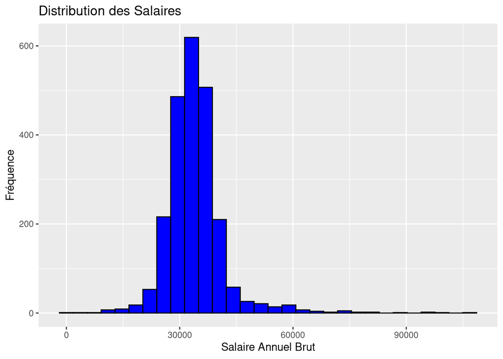

```r
library(ggplot2)
ggplot(donnees_combinees_filtrees, aes(x = remuneration_annuelle_brute)) +
  geom_histogram(bins = 30, fill = "blue",  color = "black") +
  labs(title = "Distribution des Salaires", x = "Salaire Annuel Brut", y = "Fréquence")
```

```r
  #theme_minimal() +
  #theme(text = element_text(size = 12))





#ggplot(donnees_non_recurrentes, aes(x = remuneration_annuelle_brute)) +
#  geom_histogram(bins = 40, fill = "blue", color = "black") +
#  scale_x_continuous(
#    breaks = breaks_pretty, # Utiliser les repères générés par pretty()
#    labels = scales::label_comma() # Utiliser label_comma pour un formatage correct des nombres
#  ) +
#  labs(
#    title = "Distribution des Salaires pour les Individus Non Récurrents",
#    x = "Salaire Annuel Brut",
#    y = "Fréquence"
#  ) +
#  theme_minimal() +
#  theme(text = element_text(size = 12))
```

#Boxplot pour voir la distribution des salires du nouveau jeu de données

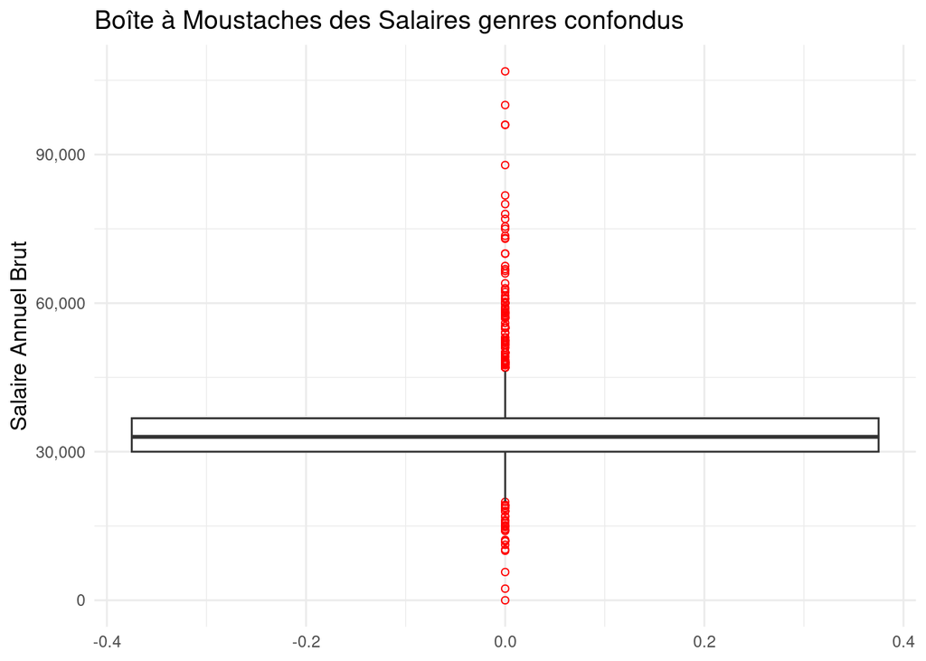

```r
# Boîte à moustaches pour voir la dispersion et les éventuels outliers
ggplot(donnees_combinees_filtrees, aes(y = remuneration_annuelle_brute)) +
  geom_boxplot(outlier.colour = "red", outlier.shape = 1) +
  scale_y_continuous(labels = scales::comma) +
  labs(title = "Boîte à Moustaches des Salaires genres confondus",
       y = "Salaire Annuel Brut") +
  theme_minimal() +
    theme(
    axis.title.y = element_text(size = 12),  # Taille de texte pour les étiquettes des axes
    plot.title = element_text(size = 14)  # Taille de texte pour le titre
  )
```

#Distribution des salaires par genre : Comme nous pouvons le voir dans les boxplots ci-dessous, lorsqu’on considère l’ensemble des filières, la médiane des rémunérations pour les femmes est légèrement inférieure à celle des hommes. Cet écart médian appuie l’hypothèse de l’existence d’une disparité salariale entre les genres.

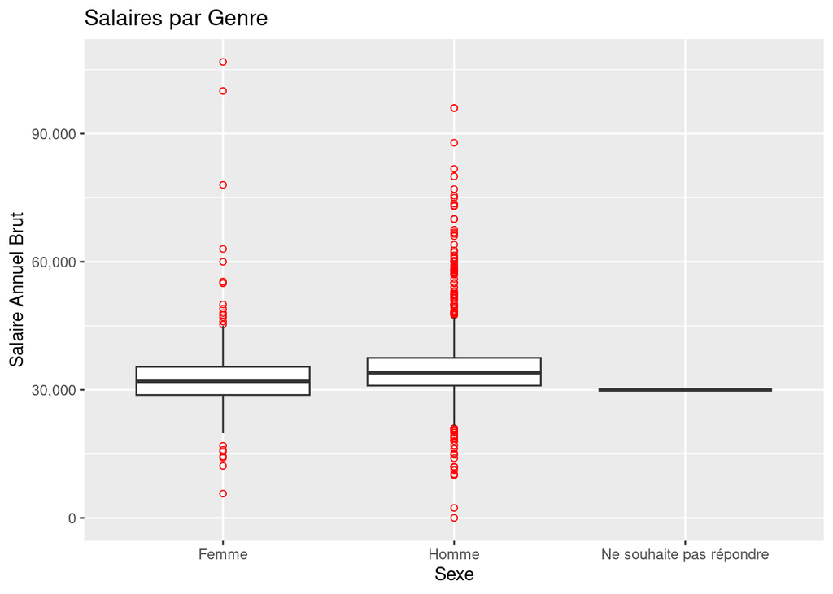

```r
ggplot(donnees_combinees_filtrees, aes(x = sexe, y = remuneration_annuelle_brute)) +
  geom_boxplot(outlier.colour = "red", outlier.shape = 1) +
  scale_y_continuous(labels = scales::comma) +
  labs(title = "Salaires par Genre", x = "Sexe", y = "Salaire Annuel Brut")
```

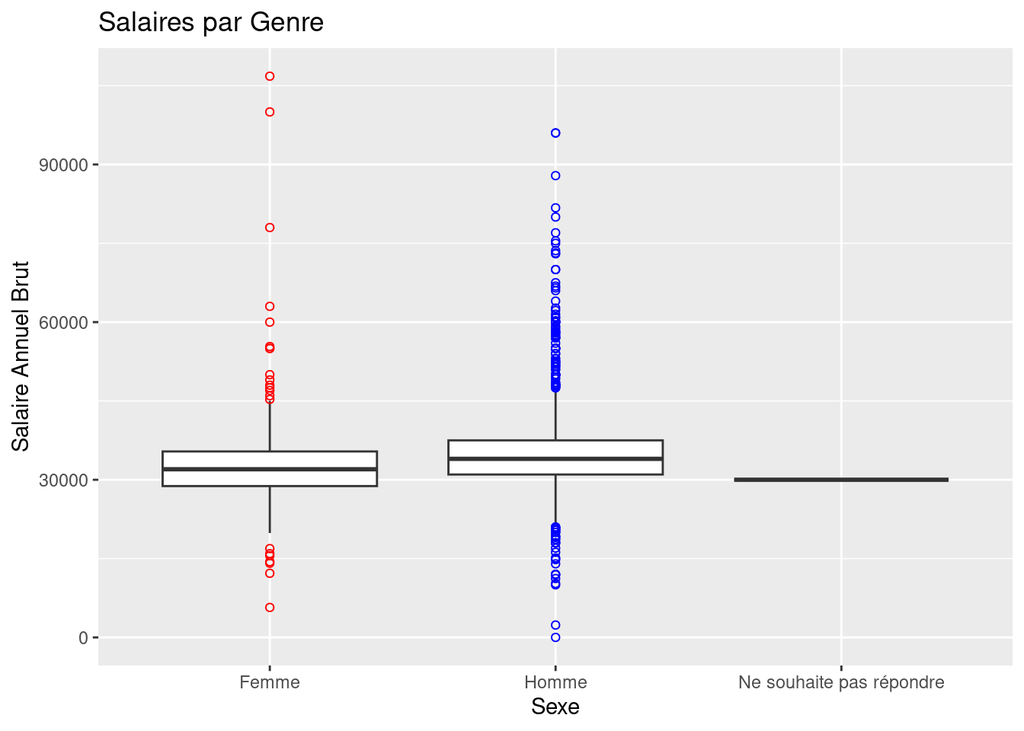

```r
# Charger la bibliothèque dplyr pour le traitement des données
library(dplyr)

# Calculer les outliers manuellement
outliers <- donnees_combinees_filtrees %>%
  group_by(sexe) %>%
  summarize(
    lower = quantile(remuneration_annuelle_brute, probs = 0.25) - 1.5 * IQR(remuneration_annuelle_brute),
    upper = quantile(remuneration_annuelle_brute, probs = 0.75) + 1.5 * IQR(remuneration_annuelle_brute),
    .groups = 'drop'  # Ajouté pour éviter les avertissements dans dplyr 1.0.0 et plus
  ) %>%
  left_join(donnees_combinees_filtrees, by = "sexe") %>%
  filter(remuneration_annuelle_brute < lower | remuneration_annuelle_brute > upper)

# Créer le boxplot de base sans outliers
base_plot <- ggplot(donnees_combinees_filtrees, aes(x = sexe, y = remuneration_annuelle_brute)) +
  geom_boxplot(outlier.shape = NA) +  # Suppression des outliers dans cette couche
  labs(title = "Salaires par Genre", x = "Sexe", y = "Salaire Annuel Brut")

# Ajouter les outliers avec des couleurs spécifiques pour chaque sexe
final_plot <- base_plot +
  geom_point(data = outliers, aes(x = sexe, y = remuneration_annuelle_brute, colour = sexe), shape = 1) +
  scale_colour_manual(values = c("Homme" = "blue", "Femme" = "red", "Ne souhaite pas répondre" = "grey")) +
  theme(legend.position = "none")  # Cache la légende

# Afficher le graphique final
print(final_plot)
```

Calcul et affichage des valeurs :

```r
# Supposons que votre dataframe s'appelle 'donnees' et la colonne de salaire 'salaire_annuel_brut'
# Et que la colonne 'sexe' contient les genres

# Extraction des statistiques pour les femmes
stats_femmes <- boxplot.stats(donnees_combinees_filtrees$remuneration_annuelle_brute[donnees_combinees_filtrees$sexe == "Femme"])

# Extraction des statistiques pour les hommes
stats_hommes <- boxplot.stats(donnees_combinees_filtrees$remuneration_annuelle_brute[donnees_combinees_filtrees$sexe == "Homme"])

# Affichage des statistiques pour les femmes
print(paste("Quartiles pour les femmes:", stats_femmes$stats))
```

```
## [1] "Quartiles pour les femmes: 19860" "Quartiles pour les femmes: 28800"
## [3] "Quartiles pour les femmes: 32000" "Quartiles pour les femmes: 35390"
## [5] "Quartiles pour les femmes: 45000"
```

```r
print(paste("Valeurs aberrantes pour les femmes:", stats_femmes$out))
```

```
##  [1] "Valeurs aberrantes pour les femmes: 1e+05"
##  [2] "Valeurs aberrantes pour les femmes: 16900"
##  [3] "Valeurs aberrantes pour les femmes: 46000"
##  [4] "Valeurs aberrantes pour les femmes: 45300"
##  [5] "Valeurs aberrantes pour les femmes: 78000"
##  [6] "Valeurs aberrantes pour les femmes: 63000"
##  [7] "Valeurs aberrantes pour les femmes: 55359.5"
##  [8] "Valeurs aberrantes pour les femmes: 15550"
##  [9] "Valeurs aberrantes pour les femmes: 47000"
## [10] "Valeurs aberrantes pour les femmes: 48000"
## [11] "Valeurs aberrantes pour les femmes: 5700"
## [12] "Valeurs aberrantes pour les femmes: 14400"
## [13] "Valeurs aberrantes pour les femmes: 14118"
## [14] "Valeurs aberrantes pour les femmes: 60000"
## [15] "Valeurs aberrantes pour les femmes: 15939"
## [16] "Valeurs aberrantes pour les femmes: 106800"
## [17] "Valeurs aberrantes pour les femmes: 55000"
## [18] "Valeurs aberrantes pour les femmes: 49000"
## [19] "Valeurs aberrantes pour les femmes: 12200"
## [20] "Valeurs aberrantes pour les femmes: 47500"
## [21] "Valeurs aberrantes pour les femmes: 50000"
## [22] "Valeurs aberrantes pour les femmes: 55000"
```

```r
# Affichage des statistiques pour les hommes
print(paste("Quartiles pour les hommes:", stats_hommes$stats))
```

```
## [1] "Quartiles pour les hommes: 21600" "Quartiles pour les hommes: 31000"
## [3] "Quartiles pour les hommes: 33980" "Quartiles pour les hommes: 37500"
## [5] "Quartiles pour les hommes: 47000"
```

```r
print(paste("Valeurs aberrantes pour les hommes:", stats_hommes$out))
```

```
##   [1] "Valeurs aberrantes pour les hommes: 51000"
##   [2] "Valeurs aberrantes pour les hommes: 73149.6666666667"
##   [3] "Valeurs aberrantes pour les hommes: 75000"
##   [4] "Valeurs aberrantes pour les hommes: 58250"
##   [5] "Valeurs aberrantes pour les hommes: 11908.5"
##   [6] "Valeurs aberrantes pour les hommes: 61000"
##   [7] "Valeurs aberrantes pour les hommes: 73600"
##   [8] "Valeurs aberrantes pour les hommes: 47500"
##   [9] "Valeurs aberrantes pour les hommes: 55000"
##  [10] "Valeurs aberrantes pour les hommes: 75466.6666666667"
##  [11] "Valeurs aberrantes pour les hommes: 0"
##  [12] "Valeurs aberrantes pour les hommes: 66500"
##  [13] "Valeurs aberrantes pour les hommes: 47500"
##  [14] "Valeurs aberrantes pour les hommes: 19200"
##  [15] "Valeurs aberrantes pour les hommes: 52270"
```

[output cut: 105 more lines]

#Nombre de personnes qui ont répondus à l’enquête par filière

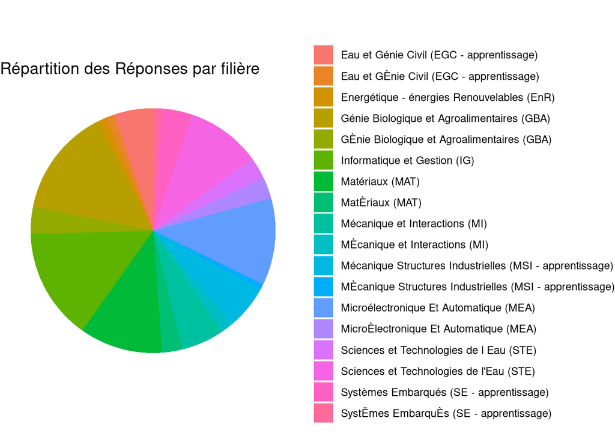

```r
library(dplyr)

reponses_par_filiere <- donnees_combinees_filtrees %>%
  group_by(filiere) %>%
  summarise(Nombre = n()) %>%
  ungroup()

library(ggplot2)

ggplot(reponses_par_filiere, aes(x = "", y = Nombre, fill = filiere)) +
  geom_bar(width = 1, stat = "identity") +
  coord_polar(theta = "y") +  # Coordonnées polaires pour le camembert
  theme_void() +  # Thème vide sans axes ni étiquettes
  theme(legend.title = element_blank()) +  # Pas de titre pour la légende
  labs(title = "Répartition des Réponses par filière", fill = "Filière")  # Nom de la légende
```

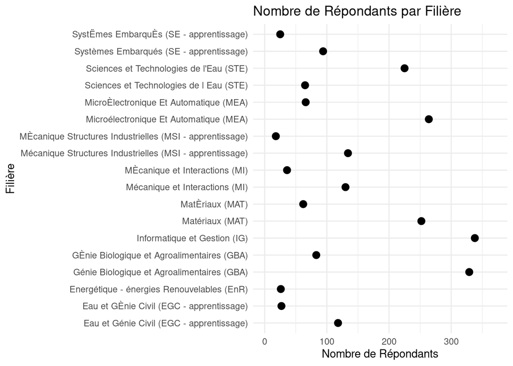

```r
# Compter le nombre de réponses par filière
comptage_filiere <- donnees_combinees_filtrees %>%
  group_by(filiere) %>%
  summarise(Nombre = n()) %>%
  ungroup()

# Créer un graphique à points
ggplot(comptage_filiere, aes(x = filiere, y = Nombre)) +
  geom_point(stat = "identity", size = 3) +  # Utilisez size pour ajuster la taille des points
  scale_y_continuous(limits = c(0, max(comptage_filiere$Nombre) * 1.1)) +  # Ajuster les limites pour un peu d'espace au-dessus du point le plus haut
  coord_flip() + # Pour une meilleure lisibilité, les filières sur l'axe Y et les comptages sur l'axe X
labs(y = "Nombre de Répondants", x = "Filière",
title = "Nombre de Répondants par Filière") +
theme_minimal() +
theme(axis.text.y = element_text(angle = 0, hjust = 1))
```

#Nombre de personnes qui ont répondus à l’enquête par genre :

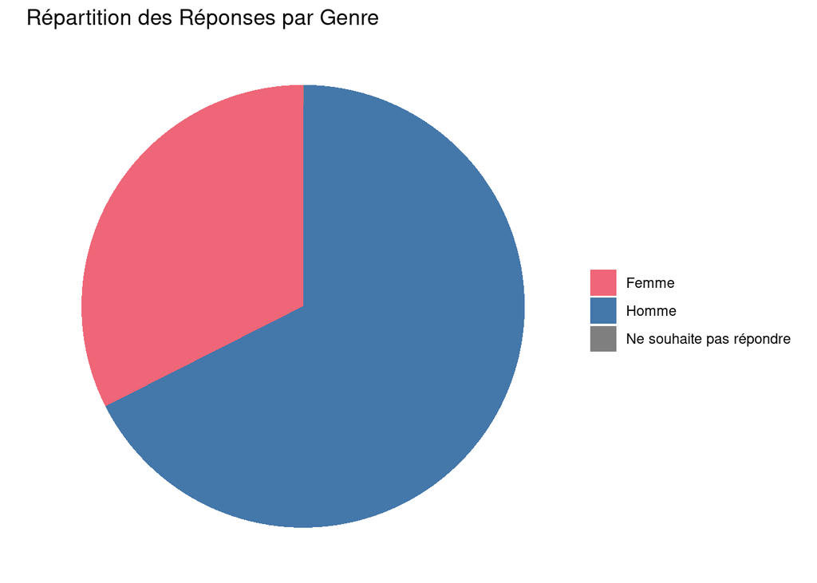

```r
# Compter le nombre de réponses par sexe
reponses_par_sexe <- donnees_combinees_filtrees %>%
  group_by(sexe) %>%
  summarise(Nombre = n()) %>%
  ungroup()

# Créer un diagramme en camembert
#ggplot(reponses_par_sexe, aes(x = "", y = Nombre, fill = sexe)) +
#  geom_bar(width = 1, stat = "identity") +
#  coord_polar(theta = "y") +  # Coordonnées polaires pour le camembert
#  theme_void() +  # Thème vide sans axes ni étiquettes
#  theme(legend.title = element_blank()) +  # Pas de titre pour la légende
#  labs(fill = "Sexe")  # Nom de la légende

ggplot(reponses_par_sexe, aes(x = "", y = Nombre, fill = sexe)) +
  geom_bar(width = 1, stat = "identity") +
  coord_polar(theta = "y") +
  theme_void() +
  scale_fill_manual(values = c("Femme" = "#EE6677",
                               "Homme" = "#4477AA",
                               "Ne souhaite pas répondre" = "grey50")) +
  labs(title = "Répartition des Réponses par Genre",
       fill = "Sexe") +
  theme(legend.title = element_blank())
```

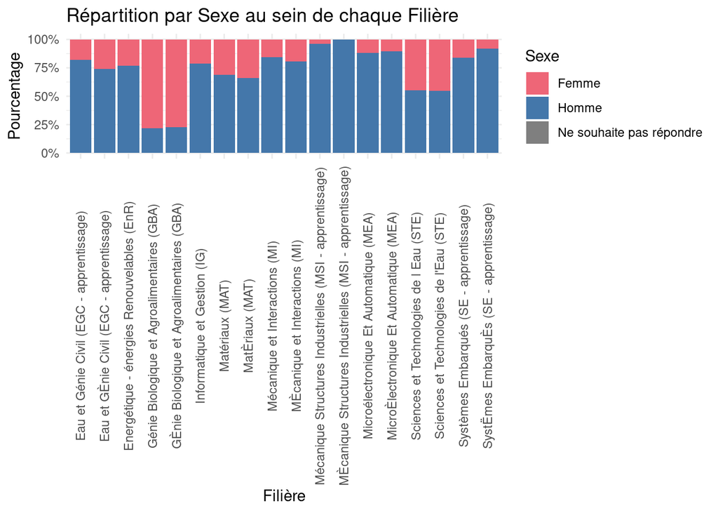

```r
# Créer un diagramme en barres empilées
ggplot(donnees_combinees_filtrees, aes(x = filiere, fill = sexe)) +
  geom_bar(position = "fill") +
  scale_y_continuous(labels = scales::percent) +
  scale_fill_manual(values = c("Homme" = "#4477AA", "Femme" = "#EE6677", "Ne souhaite pas répondre" = "grey50")) +
  labs(x = "Filière", y = "Pourcentage", fill = "Sexe",
       title = "Répartition par Sexe au sein de chaque Filière") +
  theme_minimal() +
  theme(axis.text.x = element_text(angle = 90, vjust = 0.5))
```

il existe une disparité entre les sexes dans pratiquement toutes les filières, avec une prédominance masculine notable (en tout cas parmi ceux qui ont répondus à l’enquête). GBA est la seule filère où la balance est inversée et que donc, on retrouve le taux de femmes le plus élevé avec les STE en suite.

[figure not shown]

```r
# Créer un graphique à facettes
ggplot(donnees_combinees_filtrees, aes(x = sexe, fill = sexe)) +
  geom_bar() +
  facet_wrap(~filiere) +
  labs(x = "Sexe", y = "Nombre de Répondants", fill = "Sexe",
       title = "Nombre de Répondants par Sexe et par Filière") +
  theme_minimal() +
  theme(legend.position = "bottom", strip.text.x = element_text(angle = 90))
```

#Rémunération annuelle brute par filière :

[figure not shown]

```r
library(ggplot2)

ggplot(donnees_combinees_filtrees, aes(x = filiere, y = remuneration_annuelle_brute)) +
  geom_boxplot(outlier.colour = "black", outlier.shape = 1) +
  theme(axis.text.x = element_text(angle = 90, hjust = 1)) +  # Incliner les étiquettes de l'axe x si elles sont trop longues
  labs(title = "Boxplot de la Rémunération Annuelle Brute par Filière",
       x = "Filière",
       y = "Rémunération Annuelle Brute") +
  theme_minimal()
```

En faisant les analyses avec les filières, nous nous sommes rendues compte qu’une même filière pouvait être écrite de 2 manières différentes donc il fallait normaliser les noms de filières :

```r
#Normalisation des noms de filières :
donnees_combinees_filtrees <- donnees_combinees_filtrees %>%
  mutate(
    filiere = case_when(
      filiere == "Microélectronique Et Automatique (MEA)" ~ "MEA",
      filiere == "MicroÈlectronique Et Automatique (MEA)" ~ "MEA",
      filiere == "GÈnie Biologique et Agroalimentaires (GBA)" ~ "GBA",
      filiere == "Génie Biologique et Agroalimentaires (GBA)" ~ "GBA",
      filiere == "Eau et GÈnie Civil (EGC - apprentissage)" ~ "EGC-app",
      filiere == "Eau et Génie Civil (EGC - apprentissage)" ~ "EGC-app",
      filiere == "Sciences et Technologies de l'Eau (STE)" ~ "STE",
      filiere == "Sciences et Technologies de l Eau (STE)" ~ "STE",
      filiere == "Systèmes Embarqués (SE - apprentissage)" ~ "SE-app",
      filiere == "SystËmes EmbarquÈs (SE - apprentissage)" ~ "SE-app",
      filiere == "Matériaux (MAT)" ~ "MAT",
      filiere == "MatÈriaux (MAT)"  ~ "MAT",
      filiere == "Mécanique et Interactions (MI)" ~ "MI",
      filiere == "MÈcanique et Interactions (MI)" ~ "MI",
      filiere == "Informatique et Gestion (IG)"  ~ "IG",
      filiere == "Mécanique Structures Industrielles (MSI - apprentissage)" ~ "MSI-app",
      filiere == "MÈcanique Structures Industrielles (MSI - apprentissage)" ~ "MSI-app",
      filiere == "Energétique - énergies Renouvelables (EnR)" ~ "EnR",

      # Ajoutez d'autres correspondances ici
      TRUE ~ filiere  # Conserve la valeur actuelle si aucune des conditions ci-dessus n'est remplie
    )
  )

# Liste des filières uniques
filiere_unique <- unique(donnees_combinees_filtrees$filiere)

# Afficher la liste des filières
print(filiere_unique)
```

```
##  [1] "MEA"     "GBA"     "MAT"     "EGC-app" "STE"     "SE-app"  "IG"
##  [8] "MSI-app" "MI"      "EnR"
```

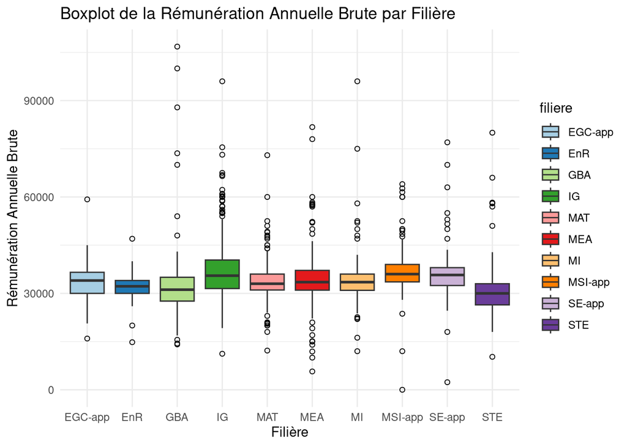

```r
ggplot(donnees_combinees_filtrees, aes(x = filiere, y = remuneration_annuelle_brute, fill = filiere)) +
  geom_boxplot(outlier.colour = "black", outlier.shape = 1) +
  scale_fill_brewer(palette = "Paired") +  # Choisissez une palette de couleurs
  theme(axis.text.x = element_text(angle = 90, hjust = 1)) +  # Incliner les étiquettes de l'axe x si elles sont trop longues
  labs(title = "Boxplot de la Rémunération Annuelle Brute par Filière",
       x = "Filière",
       y = "Rémunération Annuelle Brute") +
  theme_minimal()
```

Les boxplots avec les couleurs de filières à Polytech Montpellier :

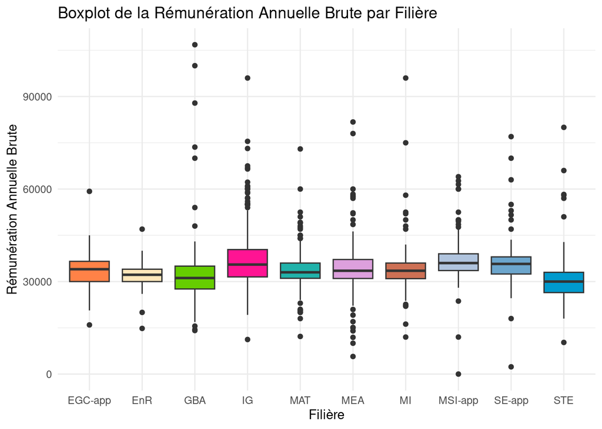

```r
ggplot(donnees_combinees_filtrees, aes(x = filiere, y = remuneration_annuelle_brute, fill = filiere)) +
  geom_boxplot() +
  scale_fill_manual(values = c("GBA" = "chartreuse3", "IG" = "deeppink1", "MEA" = "plum", "STE" = "deepskyblue3",
                               "MI"="salmon3", "SE-app"="skyblue3", "MSI-app"="lightsteelblue", "MAT"="lightseagreen", "EnR"="wheat1", "EGC-app"="sienna1")) +  # Définir les couleurs manuellement
  theme(axis.text.x = element_text(angle = 90, hjust = 1)) +  # Incliner les étiquettes de l'axe x si elles sont trop longues
  labs(title = "Boxplot de la Rémunération Annuelle Brute par Filière",
       x = "Filière",
       y = "Rémunération Annuelle Brute") +
  theme_minimal() +
  theme(legend.position = "none")
```

#Rémunération annuelle brute par filière et par sexe :

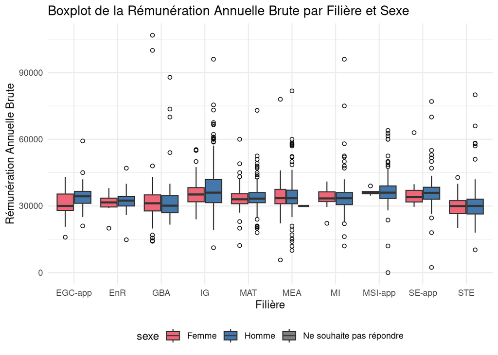

```r
ggplot(donnees_combinees_filtrees, aes(x = filiere, y = remuneration_annuelle_brute)) +
  geom_boxplot(aes(fill = sexe), position = position_dodge(0.8), outlier.colour = "black", outlier.shape = 1) +
  scale_fill_manual(values = c("Femme" = "#EE6677", "Homme" = "#4477AA", "Ne souhaite pas répondre" = "grey50")) +
  theme(axis.text.x = element_text(angle = 90, hjust = 1, vjust = 0.5)) +
  labs(title = "Boxplot de la Rémunération Annuelle Brute par Filière et Sexe",
       x = "Filière",
       y = "Rémunération Annuelle Brute") +
  theme_minimal() +
  theme(legend.position = "bottom")  # Placez la légende en bas pour économiser de l'espace
```

#Maintenant on s’intéresse à la distribution des salaires par rapport à la nationalité

```r
# Vérifier les niveaux uniques pour la nationalité française
unique(donnees_combinees_filtrees$nationalite_francaise)
```

```
## [1] "Non" "Oui" ""
```

```r
# Vérifier les niveaux uniques pour toutes les nationalités
unique(donnees_combinees_filtrees$nationalite)
```

```
##  [1] "Chinoise"      ""              "Marocaine"     "Albanaise"
##  [5] "Malienne"      "Tunisienne"    "Chypriote"     "Suisse"
##  [9] "Portugaise"    "Roumaine"      "Péruvienne"    "Sénégal"
## [13] "Camerounaise"  "Brésilienne"   "Libanaise"     "Béninoise"
## [17] "Senegalaise"   "Malaisienne"   "Italienne"     "Vénézuélienne"
## [21] "Gabonaise"     "Belge"         "BrÈsilienne"   "Ivoirienne"
## [25] "Burkina Faso " "Burkinabé"     "Malgache"      "Brésilien"
## [29] "Tchèque "      "Mauricienne"   "Nigériane"     "BURKINABE"
## [33] "Burkinabe"     "AlgÈrienne"    "Iranienne"     "Anglaise"
## [37] "Malienne "     "Cameroun "     "Algérienne"    "Peruvienne"
## [41] "Péruvienne "   "Éthiopienne "  "Allemande"
```

```r
#Normalisation des noms de filières :
donnees_combinees_filtrees <- donnees_combinees_filtrees %>%
  mutate(
    nationalite = case_when(
      nationalite == "Burkinabé" ~ "Burkinabé",
      nationalite == "BURKINABE" ~ "Burkinabé",
      nationalite == "Péruvienne" ~ "Péruvienne",
      nationalite == "Péruvienne " ~ "Péruvienne",
      nationalite == "Senegalaise" ~ "Senegalaise",
      nationalite == "Sénégal" ~ "Senegalaise",
      nationalite == "BrÈsilienne" ~ "Brésilienne",
      nationalite == "Brésilien" ~ "Brésilienne",
      nationalite == "Brésilienne" ~ "Brésilienne",
      nationalite == "AlgÈrienne" ~ "Algérienne",
      nationalite == "Algérienne" ~ "Algérienne",
      nationalite == "Malienne "  ~ "Malienne",

      # Ajoutez d'autres correspondances ici
      TRUE ~ nationalite  # Conserve la valeur actuelle si aucune des conditions ci-dessus n'est remplie
    )
  )

# Liste des filières uniques
nationalite_unique <- unique(donnees_combinees_filtrees$nationalite)

# Afficher la liste des filières
print(nationalite_unique)
```

```
##  [1] "Chinoise"      ""              "Marocaine"     "Albanaise"
##  [5] "Malienne"      "Tunisienne"    "Chypriote"     "Suisse"
##  [9] "Portugaise"    "Roumaine"      "Péruvienne"    "Senegalaise"
## [13] "Camerounaise"  "Brésilienne"   "Libanaise"     "Béninoise"
## [17] "Malaisienne"   "Italienne"     "Vénézuélienne" "Gabonaise"
## [21] "Belge"         "Ivoirienne"    "Burkina Faso " "Burkinabé"
## [25] "Malgache"      "Tchèque "      "Mauricienne"   "Nigériane"
## [29] "Burkinabe"     "Algérienne"    "Iranienne"     "Anglaise"
## [33] "Cameroun "     "Peruvienne"    "Éthiopienne "  "Allemande"
```

#Proportion des personnes qui ont répondus à la question de s’ils ont la nationalité française ou pas :

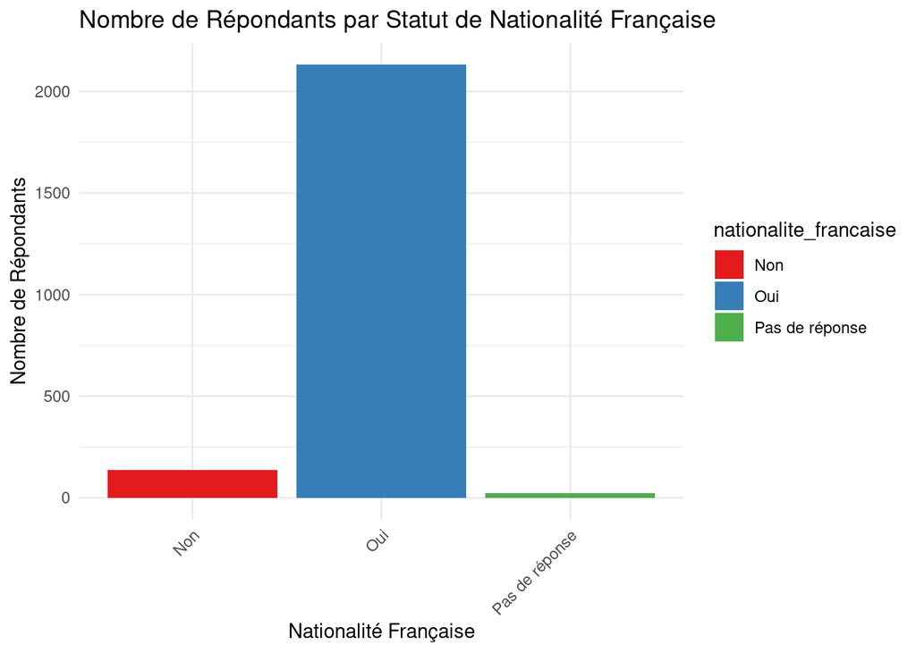

```r
# Compter le nombre de réponses par catégorie de nationalité française
reponses_nationalite <- donnees_combinees_filtrees %>%
  mutate(nationalite_francaise = ifelse(nationalite_francaise == "", "Pas de réponse", nationalite_francaise)) %>%
  count(nationalite_francaise) %>%
  ungroup()

# Créer un diagramme en barres
ggplot(reponses_nationalite, aes(x = nationalite_francaise, y = n, fill = nationalite_francaise)) +
  geom_bar(stat = "identity") +
  labs(x = "Nationalité Française", y = "Nombre de Répondants",
       title = "Nombre de Répondants par Statut de Nationalité Française") +
  scale_fill_brewer(palette = "Set1") +
  theme_minimal() +
  theme(axis.text.x = element_text(angle = 45, hjust = 1))
```

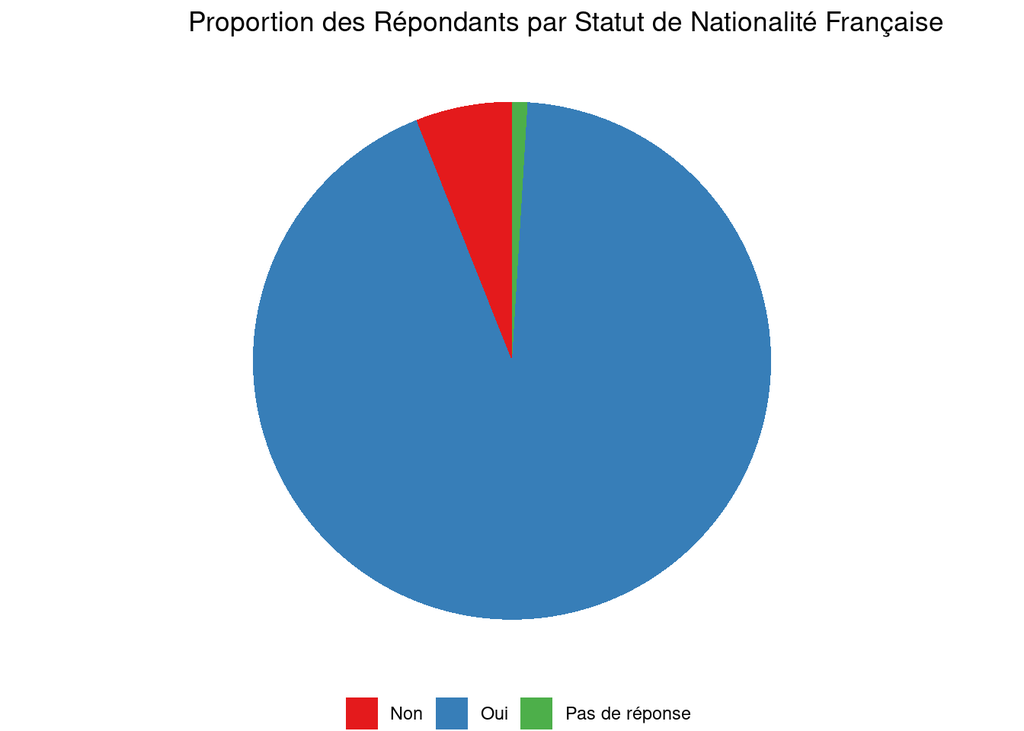

```r
# Créer un diagramme en camembert
ggplot(reponses_nationalite, aes(x = "", y = n, fill = nationalite_francaise)) +
  geom_bar(width = 1, stat = "identity") +
  coord_polar(theta = "y") +
  labs(fill = "Nationalité Française",
       title = "Proportion des Répondants par Statut de Nationalité Française") +
  scale_fill_brewer(palette = "Set1") +
  theme_void() +
  theme(legend.title = element_blank(), legend.position = "bottom")
```

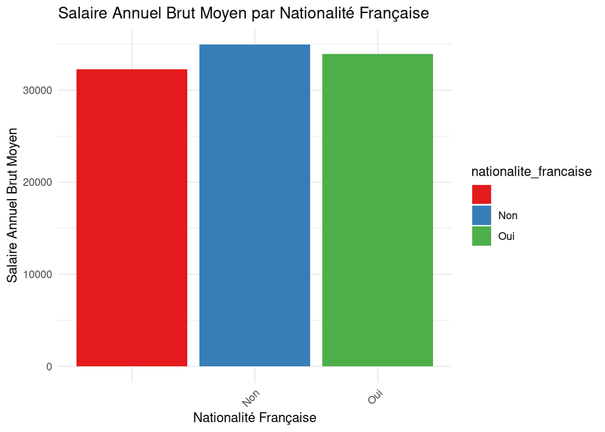

```r
# Calculer la moyenne des salaires par catégorie de nationalité française
moyenne_salaire_par_nationalite <- donnees_combinees_filtrees %>%
  group_by(nationalite_francaise) %>%
  summarise(moyenne_salaire = mean(remuneration_annuelle_brute, na.rm = TRUE)) %>%
  ungroup()

# Créer un graphique à barres des moyennes
ggplot(moyenne_salaire_par_nationalite, aes(x = nationalite_francaise, y = moyenne_salaire, fill = nationalite_francaise)) +
  geom_bar(stat = "identity", position = "dodge") +
  labs(x = "Nationalité Française", y = "Salaire Annuel Brut Moyen", title = "Salaire Annuel Brut Moyen par Nationalité Française") +
  scale_fill_brewer(palette = "Set1") +
  theme_minimal() +
  theme(axis.text.x = element_text(angle = 45, hjust = 1))
```

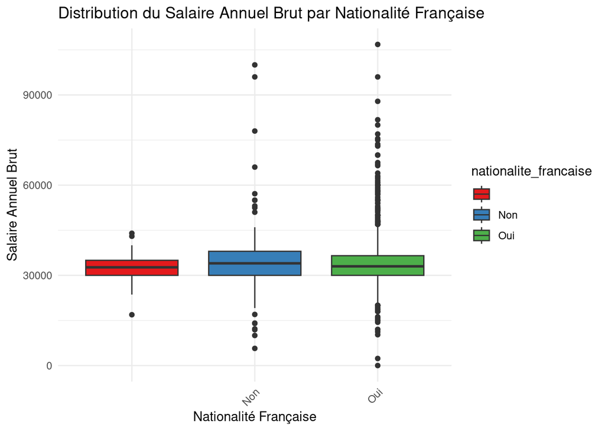

```r
ggplot(donnees_combinees_filtrees, aes(x = nationalite_francaise, y = remuneration_annuelle_brute, fill = nationalite_francaise)) +
  geom_boxplot() +
  labs(x = "Nationalité Française", y = "Salaire Annuel Brut", title = "Distribution du Salaire Annuel Brut par Nationalité Française") +
  scale_fill_brewer(palette = "Set1") +
  theme_minimal() +
  theme(axis.text.x = element_text(angle = 45, hjust = 1))
```

#Traitement des NA pour la colonne de nationalite_française :

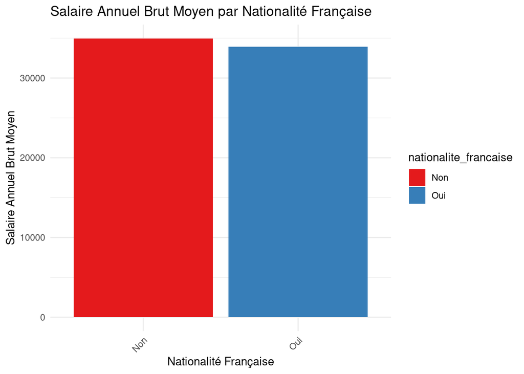

```r
donnees_nettoyees_nationalite <- donnees_combinees_filtrees %>%
  mutate(nationalite_francaise = ifelse(nationalite_francaise == "", "Inconnue", nationalite_francaise)) %>%
  # Vous pouvez également choisir d'exclure les lignes avec des valeurs vides
  filter(nationalite_francaise != "Inconnue")

# Calculer la moyenne des salaires par catégorie de nationalité française
moyenne_salaire_par_nationalite <- donnees_nettoyees_nationalite %>%
  group_by(nationalite_francaise) %>%
  summarise(moyenne_salaire = mean(remuneration_annuelle_brute, na.rm = TRUE)) %>%
  ungroup()

# Créer un graphique à barres des moyennes
ggplot(moyenne_salaire_par_nationalite, aes(x = nationalite_francaise, y = moyenne_salaire, fill = nationalite_francaise)) +
  geom_bar(stat = "identity", position = "dodge") +
  labs(x = "Nationalité Française", y = "Salaire Annuel Brut Moyen", title = "Salaire Annuel Brut Moyen par Nationalité Française") +
  scale_fill_brewer(palette = "Set1") +
  theme_minimal() +
  theme(axis.text.x = element_text(angle = 45, hjust = 1))
```

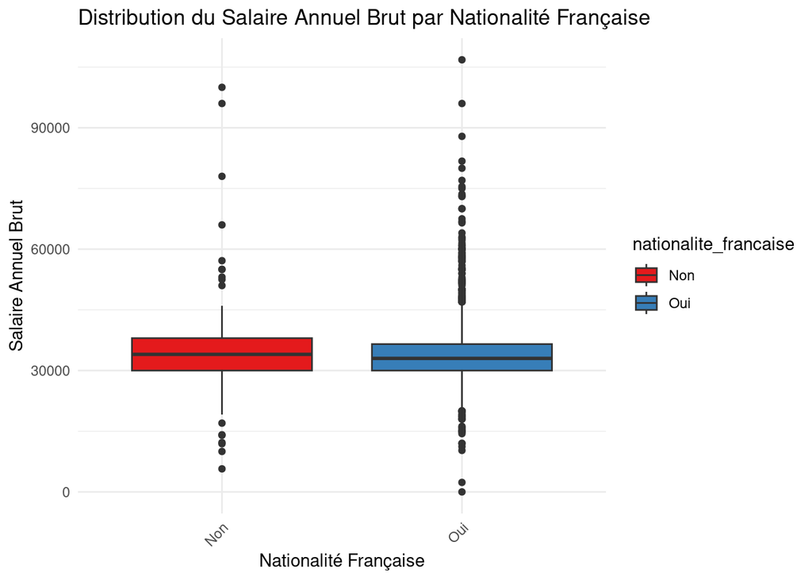

```r
ggplot(donnees_nettoyees_nationalite, aes(x = nationalite_francaise, y = remuneration_annuelle_brute, fill = nationalite_francaise)) +
  geom_boxplot() +
  labs(x = "Nationalité Française", y = "Salaire Annuel Brut", title = "Distribution du Salaire Annuel Brut par Nationalité Française") +
  scale_fill_brewer(palette = "Set1") +
  theme_minimal() +
  theme(axis.text.x = element_text(angle = 45, hjust = 1))
```

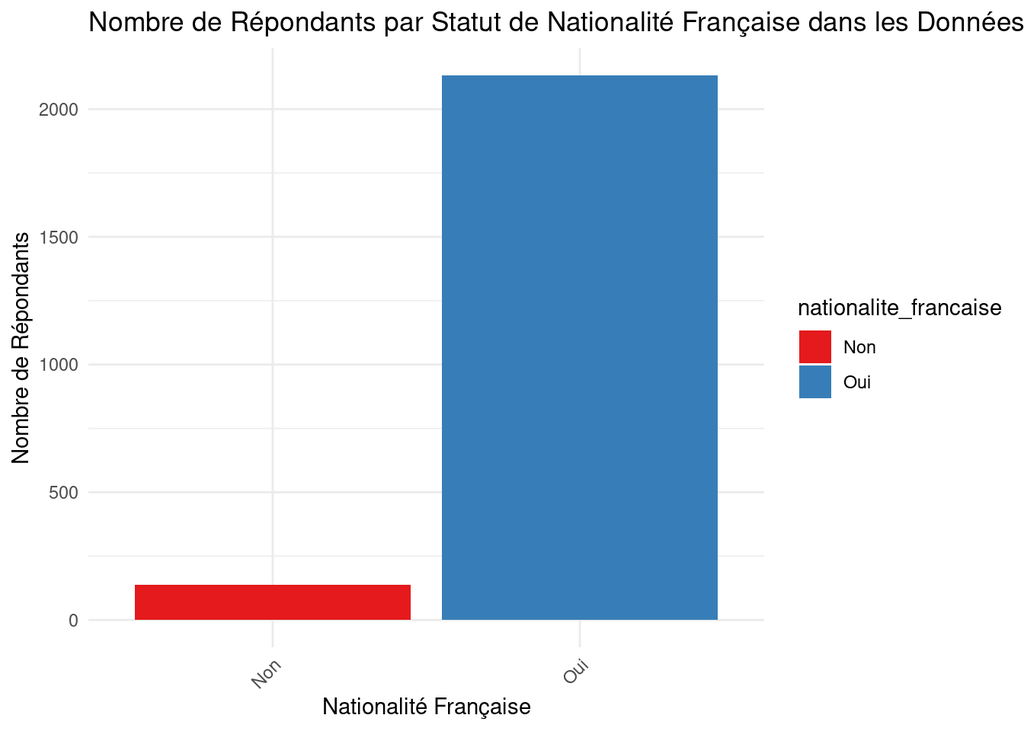

```r
# Compter le nombre de réponses par catégorie de nationalité française dans donnees_nettoyees
reponses_nationalite_nettoyees <- donnees_nettoyees_nationalite %>%
  count(nationalite_francaise) %>%
  ungroup()

# Créer un diagramme en barres pour donnees_nettoyees
ggplot(reponses_nationalite_nettoyees, aes(x = nationalite_francaise, y = n, fill = nationalite_francaise)) +
  geom_bar(stat = "identity") +
  labs(x = "Nationalité Française", y = "Nombre de Répondants",
       title = "Nombre de Répondants par Statut de Nationalité Française dans les Données Nettoyées") +
  scale_fill_brewer(palette = "Set1") +
theme_minimal() +
theme(axis.text.x = element_text(angle = 45, hjust = 1))
```

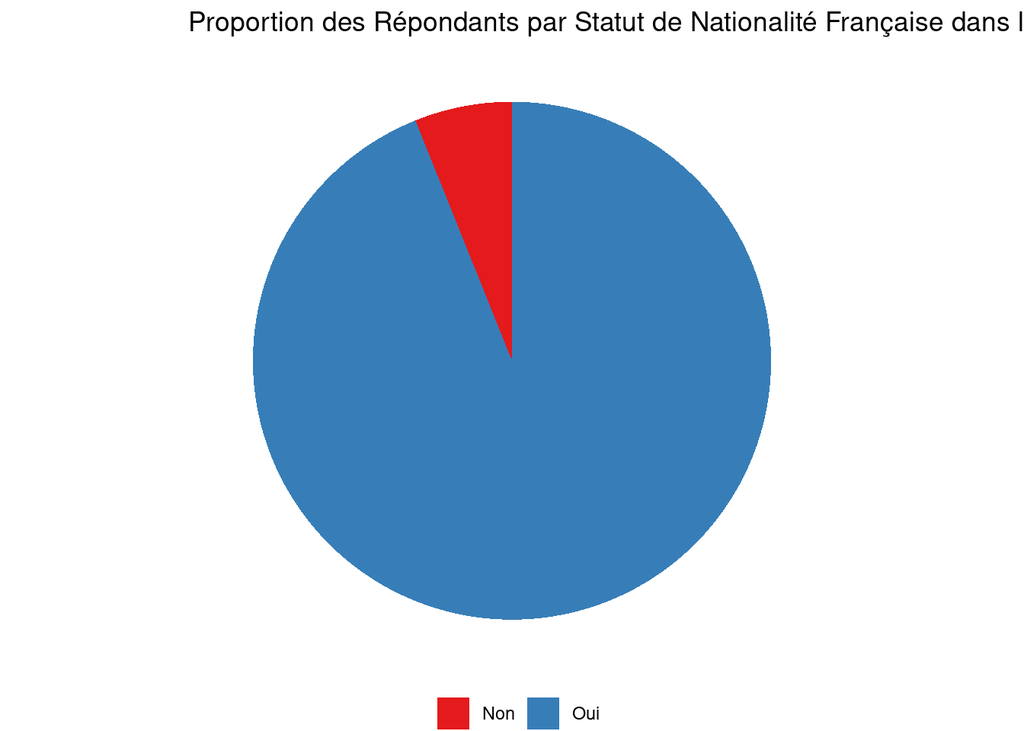

```r
# Créer un diagramme en camembert pour donnees_nettoyees
ggplot(reponses_nationalite_nettoyees, aes(x = "", y = n, fill = nationalite_francaise)) +
  geom_bar(width = 1, stat = "identity") +
  coord_polar(theta = "y") +
  labs(fill = "Nationalité Française",
       title = "Proportion des Répondants par Statut de Nationalité Française dans les Données Nettoyées") +
  scale_fill_brewer(palette = "Set1") +
  theme_void() +
  theme(legend.title = element_blank(), legend.position = "bottom")
```

```r
# Exporter vers un fichier CSV
write.csv(donnees_combinees_filtrees, file = "donnees_combinees_filtrees.csv", row.names = FALSE)
```

#Nombre de personnes selon les nationalités :

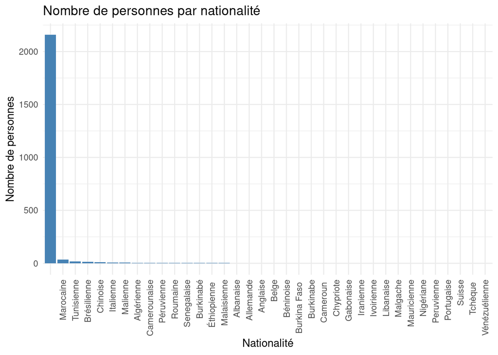

```r
# Chargement des librairies nécessaires
library(ggplot2)
library(dplyr)

# Préparation des données pour le comptage
nationalite_counts <- donnees_combinees_filtrees %>%
  group_by(nationalite) %>%
  summarise(Nombre = n(), .groups = 'drop') %>%
  arrange(desc(Nombre))

# Création d'un diagramme en barres
ggplot(nationalite_counts, aes(x = reorder(nationalite, -Nombre), y = Nombre)) +
  geom_bar(stat = "identity", fill = "steelblue") +
  labs(x = "Nationalité", y = "Nombre de personnes",
       title = "Nombre de personnes par nationalité") +
  theme_minimal() +
  theme(axis.text.x = element_text(angle = 90, hjust = 1, vjust = 0.5))  # Incliner les étiquettes pour une meilleure lisibilité
```

#Boxplot des salaires par nationalité :

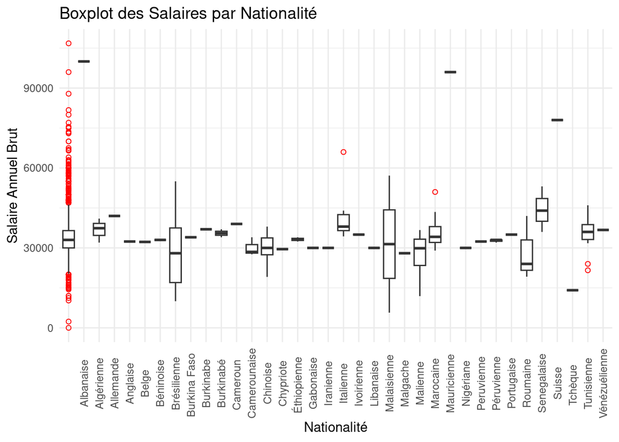

```r
# Chargement des librairies nécessaires
library(ggplot2)

# Création d'un boxplot des salaires par nationalité
ggplot(donnees_combinees_filtrees, aes(x = nationalite, y = remuneration_annuelle_brute)) +
  geom_boxplot(outlier.colour = "red", outlier.shape = 1 ) +
  labs(x = "Nationalité", y = "Salaire Annuel Brut",
       title = "Boxplot des Salaires par Nationalité") +
  theme_minimal() +
  theme(axis.text.x = element_text(angle = 90, vjust = 0.5))  # Incliner les étiquettes pour une meilleure lisibilité
```

```r
# Regroupement des nationalités moins fréquentes sous une catégorie "Autre"
#seuil <- 10  # Définir le seuil selon votre jeu de données
#nationalite_counts <- donnees_combinees_filtrees %>%
 # group_by(nationalite) %>%
#  summarise(Count = n(), .groups = 'drop')

# Créer une nouvelle colonne pour le regroupement
#donnees_combinees_filtrees <- donnees_combinees_filtrees %>%
 # mutate(nationalite_grouped = ifelse(nationalite %in% nationalite_counts$nationalite[nationalite_counts$Count < seuil], "Autre", nationalite))

# Convertir la nouvelle colonne en facteur
#donnees_combinees_filtrees$nationalite_grouped <- factor(donnees_combinees_filtrees$nationalite_grouped)

# Création d'un boxplot avec les nationalités regroupées
#ggplot(donnees_combinees_filtrees, aes(x = nationalite_grouped, y = remuneration_annuelle_brute)) +
 # geom_boxplot() +
  #labs(x = "Nationalité", y = "Salaire Annuel Brut",
   #    title = "Boxplot des Salaires par Nationalité avec Regroupement") +
  #theme_minimal() +
  #theme(axis.text.x = element_text(angle = 90, vjust = 0.5))
```

Calcul des premiers, troisièmes quartiles et de la médiane pour chaque filière :

```r
# Pour chaque filière, calculer les quartiles et la médiane
quartiles_medianes <- donnees_combinees_filtrees %>%
  group_by(filiere) %>%
  summarise(
    Q1 = quantile(remuneration_annuelle_brute, 0.25, na.rm = TRUE),
    Mediane = median(remuneration_annuelle_brute, na.rm = TRUE),
    Q3 = quantile(remuneration_annuelle_brute, 0.75, na.rm = TRUE)
  )

# Afficher les résultats
print(quartiles_medianes)
```

```
## # A tibble: 10 × 4
##    filiere     Q1 Mediane     Q3
##    <chr>    <dbl>   <dbl>  <dbl>
##  1 EGC-app 30000    34000 36558.
##  2 EnR     30000    32200 34000
##  3 GBA     27600    31150 35000
##  4 IG      31500    35510 40375
##  5 MAT     31050    33000 36000
##  6 MEA     31000    33500 37150
##  7 MI      30942.   33500 36000
##  8 MSI-app 33575    36000 39000
##  9 SE-app  32450    35720 38000
## 10 STE     26425    30000 33000
```

Remarque : Nous avons fait d’autres diagrammes et nous faisions des commits directements sur le terminal de R et à chaque fois que nous ouvrions le document markdown, nous ne les trouvions pas. Le problème était que le terminal en R ne fonctionnait pas très bien pour les commits et ça nous a fait perdre du travail.

Explications supplémentaires : * Nous avons remarqué qu’il y avait 578 occurences avec des identifiants sous forme scientifique “1,76719E+15” avec des individus qui ont répondu plusieurs fois. Au début nous ne comprenions pas pourquoi et comment c’est possible. Après nous nous sommes rendues compte que le fichiers 2019, les identifiants étaient sous la forme scientifique ( et là c’est devenu logique, parce que les individus avec les identifiants complets, l’occurence de leurs réponses maximum était de 3 fois, ce qui était logique car en tout, un individu devait répondre à l’enquête 3 fois maximum : une fois à 6mois, une à 18mois et une à 30mois.

```
Solution : nous avons homogéneisé la colonne identifiant dans le fichier 2019 en faisant une conversion :
              data2019$identifiant <- as.numeric(format(data2019$identifiant, scientific = FALSE))
```

# Data Frame Explications

- donnees_totales c’est le data frame qui contient toutes les données des 6 fichiers avec les colonnes suivantes : sexe, identifiant, date_diplome, filiere, remuneration_annuelle_brute, prime, remuneration_prime, remuneration_annuelle_brute_hors_prime_premier_emploi, nationalite_francaise,nationalite, prime_premier_emploi, remuneration_annuelle_brute_avec_prime_premier_emploi
- donnees_recurrentes les données seulement avec les entrées avec des identifiants récurrents
- donnees_non_recurrentes les données seulement avec les entrées avec des identifiants non récurrents
- donnees_combinees Combinaison des salaires moyens des individus réccurents et de ceux non réccurents
- salaire_moyen_individus_recurrents Pour les individus réccurents, c’est un data frame où on trouve pour chaque individu, la moyenne de son salaire (selon les différentes colonnes ) et où on prend les premières réponses pour les autres colonnes et on garde qu’une ligne par individu
- donnees_combinees_filtrees C’est les donnees_combinees sur lesquelles nous avons effectué un filtrage pour enlever les lignes des individus qui n’ont pas répondu à la question du montant de leurs rémuneration annuelle brute. Dans notre étude nous nous intéressons particulièrement aux données liées au salaire et donc nous n’avons pas vraiment besoin des données des individus qui n’ont pas répondu aux questions liées au salaire.
- donnees_nettoyees_nationalite c’est les donnees_combinees_filtrees mais en ignorant les NA dans la colonne nationalite_francaise